# Linear Model Evaluation: Model Assumptions

## Linear Model Evaluation: the big picture

[figure not shown]

**Evaluation: Is our model useful?**

- Does the model satisfy its assumptions?
- Is the model accurate? Does it predict new observations well?

## Linear model assumptions

Recall that we can write an individual response from a linear model \(y_i\) as

\[ y_i = \beta_0 + \beta_1 x_{i1} + \beta_2 x_{i2} + ... + \beta_p x_{ip} + \varepsilon_i. \space \space (1) \] When we use a linear model, we assume

\[ \varepsilon_i \stackrel{\text{ind}}{\sim} N(0,\sigma^2). \space \space (2) \]

**Four assumptions for the error term**

- Normally distributed
- Consistently have a mean of zero (no trend)
- Constant variance, or spread.
- Independence

We can check the model assumptions by looking at plots of the residuals from our fitted model.

## Normality assumption

\(\varepsilon_i \stackrel{\text{ind}}{\sim}\) \(N\) \((0,\sigma^2)\)

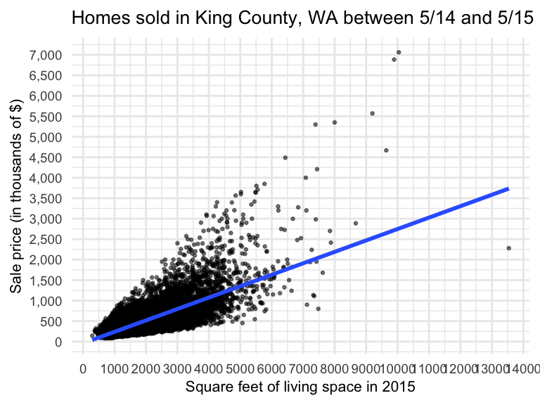

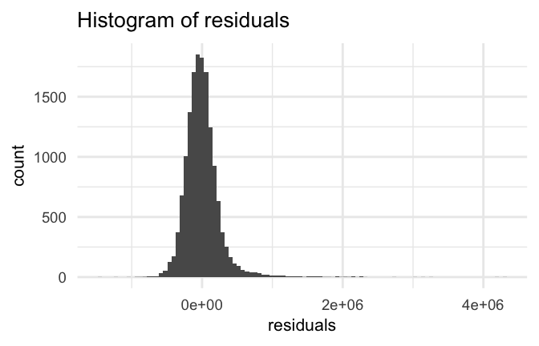

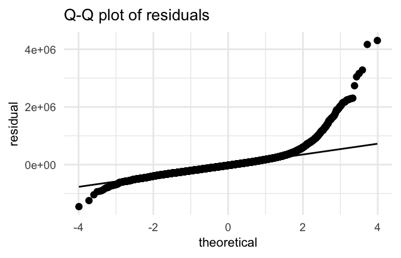

## Normality assumption (Q-Q plot detail)

| price_hat | residual | resid_rank | resid_percentile | norm_quantile |
| --- | --- | --- | --- | --- |
| 3735045 | -1455045 | 1 | 0.0001 | -3.82 |
| 2045048 | -1245048 | 2 | 0.0001 | -3.65 |
| 1944652 | -1044652 | 3 | 0.0002 | -3.54 |
| 1481995 | -936995 | 4 | 0.0003 | -3.47 |
| 2019949 | 3280051 | 15128 | 0.9998 | 3.54 |
| 2717143 | 4167857 | 15129 | 0.9999 | 3.65 |
| 2758974 | 4303526 | 15130 | 0.9999 | 3.82 |

For more detail of how the Q-Q plot is constructed see: https://www.youtube.com/watch?v=X9_ISJ0YpGw

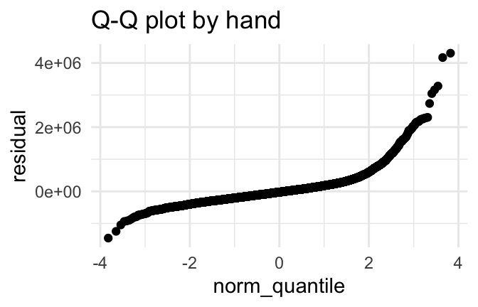

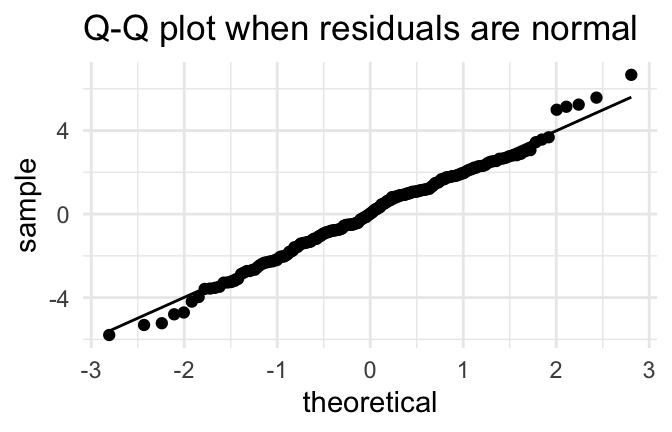

## Mean zero / no trend assumption

\(\varepsilon_i \stackrel{\text{ind}}{\sim} N(\) \(0\) \(,\sigma^2)\)

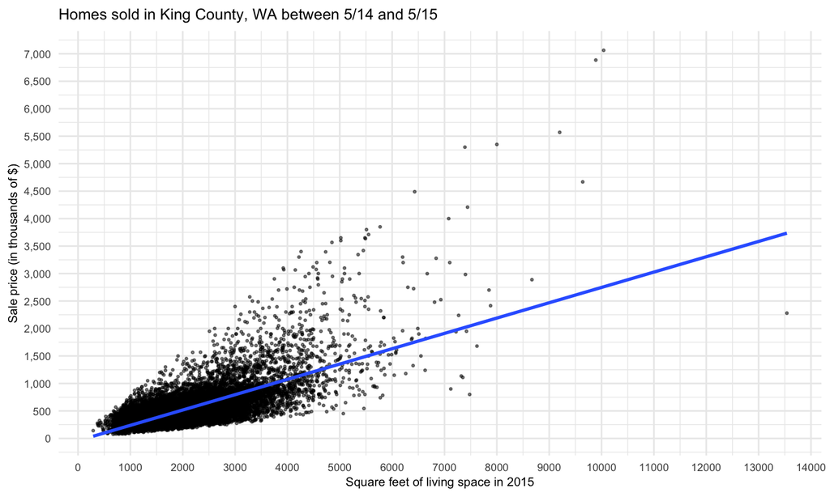

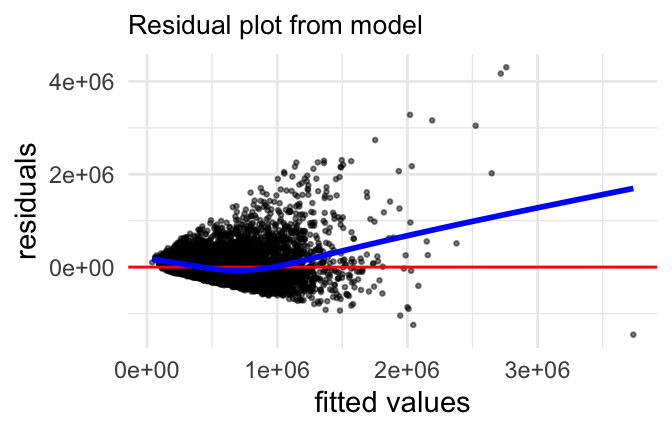

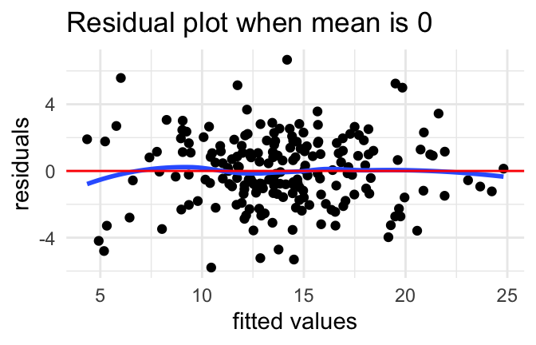

## Constant variance assumption

\(\varepsilon_i \stackrel{\text{ind}}{\sim} N(0,\) \(\sigma^2\) \()\)

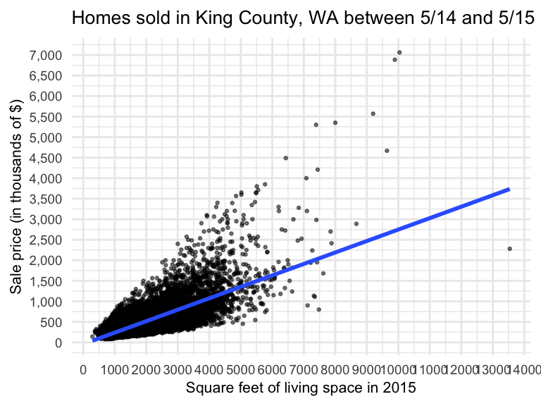

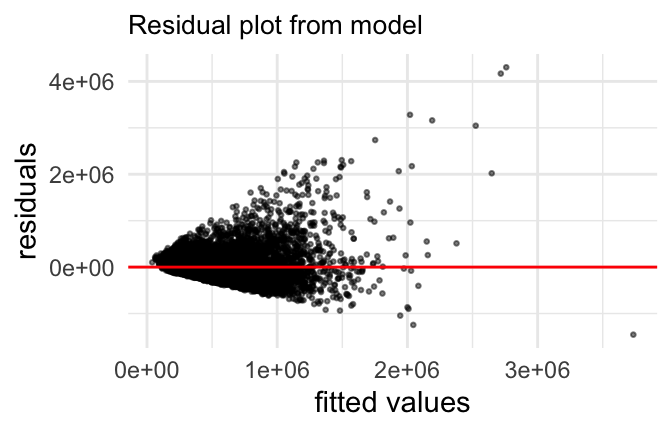

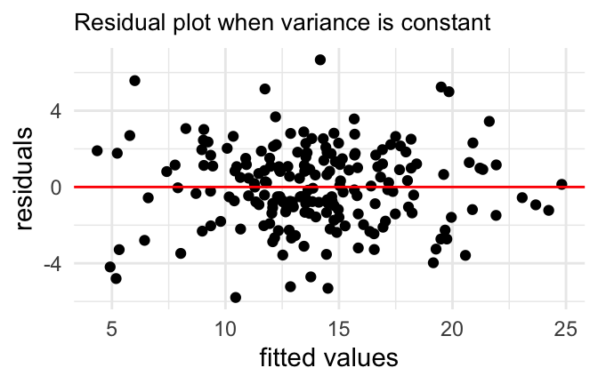

## Independence assumption

\(\varepsilon_i\) \(\stackrel{\text{ind}}{\sim}\) \(N(0,\sigma^2)\)

Implies that knowing the error for one observation does not provide any information about the error of another observation. This means the errors are not correlated with one another.

There are plots that can be used to check this assumption, but they require you to know something about how the observations may be correlated.

When might we see correlated data?

- Longitudinal: data collected on same subjects or observations over time
- Spatial: data from certain areas have similar responses (ie. prices of homes in different neighborhoods)
- Nested data: students within classrooms, patients within clinics

It is important to have a good understanding of where the data came from and how it was collected so you can evaluate if there might be a risk of this assumption being violated. If it is, you will need to account for that using methods we will not discuss in this course. But if you’re interested, you should take correlated data!

## Summary

| Assumption | How to check | Problems | Fix |
| --- | --- | --- | --- |
| Normality | Histogram or Q-Q plot | Inaccurate statistical inference | Transform response variable |
| Mean 0 / No Trend | Residuals vs. fitted values | Poor predictive accuracy | Transform predictor variable(s) |
| Constant Variance / Homoscedasticity | Residuals vs. fitted values | Inaccurate statistical inference | Transform response variable |
| Independence | Know the data | Inaccurate statistical inference | Use correlated data methods |

*Table adapted from Leslie Myint*

## Other considerations: multicollinearity

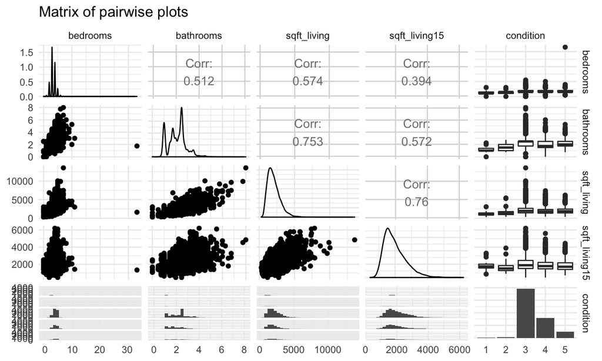

## Other considerations: multicollinearity & near-zero variance

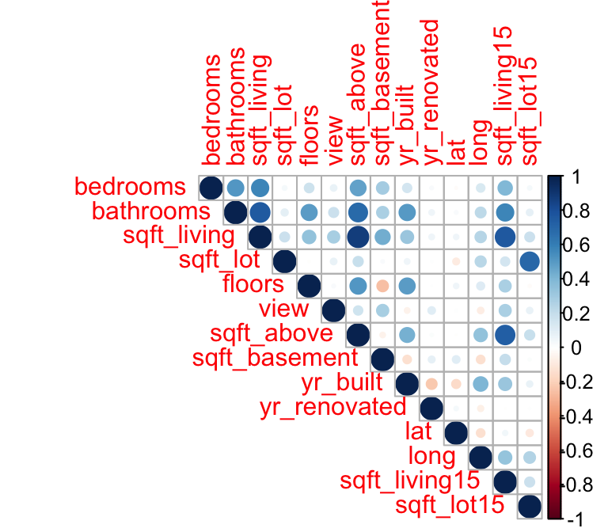

Near zero variance statistics

| variable | freqRatio | percentUnique |
| --- | --- | --- |
| view | 20.4 | 0.03 |
| sqft_basement | 58.6 | 1.82 |
| yr_renovated | 223.0 | 0.43 |

## Implementing in R: setup splits

Load libraries and set plot theme.

```r
library(tidyverse) #for plotting and summarizing
library(broom) #for nice model output
library(knitr) #for nice tables
library(moderndive) #for house_prices dataset
library(rsample) #for splitting data
library(recipes) #for transformations
library(scales) #for nice labels on graphs
library(GGally) #for nice pairwise plot matrix
library(corrplot) #for basic corr. matrix plot
theme_set(theme_minimal())
```

Load data, `set.seed()`, and split data.

```r
data("house_prices")
set.seed(4839) #for reproducibility
house_split <- initial_split(house_prices,
                             prop = .7)
house_train <- training(house_split)
house_test <- testing(house_split)
```

Fit a simple model and print the model output.

```r
house_simple_lm <- lm(price ~ sqft_living,
                      data = house_train)
tidy(house_simple_lm)
```

| term | estimate | std.error | statistic | p.value |
| --- | --- | --- | --- | --- |
| (Intercept) | -40954 | 5277.9 | -7.8 | 0 |
| sqft_living | 279 | 2.3 | 119.9 | 0 |

## Implementing in R: the `augment()` function

```r
augment(house_simple_lm)
```

First 5 rows of augmented data from the model.

| price | sqft_living | .fitted | .resid |
| --- | --- | --- | --- |
| 221900 | 1180 | 288121.1 | -66221.14 |
| 510000 | 1680 | 427559.8 | 82440.20 |
| 1225000 | 5420 | 1470560.9 | -245560.94 |
| 257500 | 1715 | 437320.5 | -179820.51 |
| 291850 | 1060 | 254655.9 | 37194.13 |

Using `augment()` to plot the fitted line

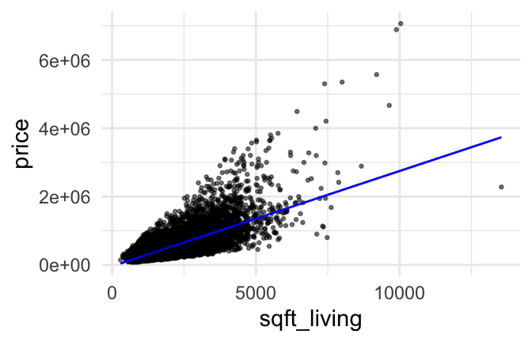

```r
augment(house_simple_lm) %>%
  ggplot() +
  geom_point(aes(x = sqft_living, price),
              alpha = .5, size = .5) +
  geom_line(aes(x = sqft_living, .fitted),
            color = "blue")
```

## Implementing in R: assumption plots

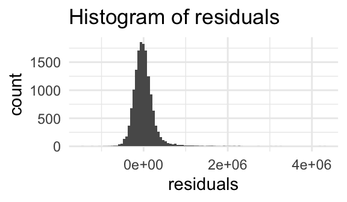

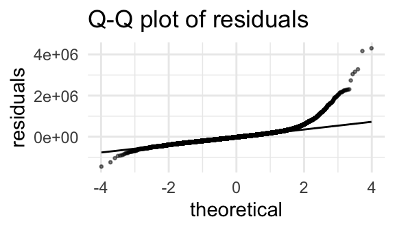

[figure not shown]

```r
augment(house_simple_lm) %>%
  ggplot(aes(x = .resid)) +
  geom_histogram(bins = 100) +
  labs(x = "residuals",
       title = "Histogram of residuals")

augment(house_simple_lm) %>%
  ggplot(aes(sample = .resid)) +
  geom_qq(alpha = .5, size = .5) +
  geom_qq_line() +
  labs(title = "Q-Q plot of residuals",
       y = "residuals")

augment(house_simple_lm) %>%
  ggplot(aes(x = .fitted, y = .resid)) +
  geom_point(alpha = .5, size = .5) +
  labs(x = "fitted values", y = "residuals") +
  geom_hline(yintercept = 0, color = "red")+
  labs(title = "Residuals vs fitted values")
```